# Student Performance Analysis

### This project investigates whether being in a romantic relationship is associated with differences in academic performance among high school students. Using the UCI Student Performance dataset which includes demographic, behavioral, and academic variables. The analysis focuses on the relationship between the romantic feature and final grade outcomes (G3). This question is relevant because romantic involvement may influence time management, stress levels, and study habits, potentially affecting academic achievement (positively, negatively, or not at all).

```python
# Imports
import pandas as pd
import numpy as np
import matplotlib.pyplot as plt
import seaborn as sns
from sklearn.model_selection import train_test_split, cross_val_score
from sklearn.preprocessing import StandardScaler
from sklearn.linear_model import LinearRegression
from sklearn.metrics import mean_squared_error, r2_score, mean_absolute_error
```

```python
# Connect to Google Drive
from google.colab import drive
drive.mount('/content/drive')
print("Google Drive connected!")
```

```
Google Drive connected!
```

```python
# Importing data
data = pd.read_csv('/content/drive/My Drive/MATH_237/Datasets/student-mat.csv', sep=';')
```

# Exploring the Data

The dataset was loaded and examined for missing values. Later in the code notebook, the categorical variable representing relationship status (“romantic”) will be encoded into a binary numeric column (romantic_encoded) to make it suitable for modeling. Only numeric features were selected for regression, and the dataset was standardized using StandardScaler to ensure that all variables were placed on comparable scales.

```python
print("First few rows:")
print(data.head())
print()

print("Dataset info:")
print(data.info())
print()

# Check for missing values
print("Missing values:")
print(data.isnull().sum())
print()

print("Romantic Relationship Distribution:")
print(data['romantic'].value_counts())
print()

print("Final Grade (G3) Statistics:")
print(data['G3'].describe())
print()
```

```
First few rows:
  school sex  age address famsize Pstatus  Medu  Fedu     Mjob      Fjob  ...  \
0     GP   F   18       U     GT3       A     4     4  at_home   teacher  ...
1     GP   F   17       U     GT3       T     1     1  at_home     other  ...
2     GP   F   15       U     LE3       T     1     1  at_home     other  ...
3     GP   F   15       U     GT3       T     4     2   health  services  ...
4     GP   F   16       U     GT3       T     3     3    other     other  ...

  famrel freetime  goout  Dalc  Walc health absences  G1  G2  G3
0      4        3      4     1     1      3        6   5   6   6
1      5        3      3     1     1      3        4   5   5   6
2      4        3      2     2     3      3       10   7   8  10
3      3        2      2     1     1      5        2  15  14  15
4      4        3      2     1     2      5        4   6  10  10

[5 rows x 33 columns]

Dataset info:
<class 'pandas.core.frame.DataFrame'>
RangeIndex: 395 entries, 0 to 394
Data columns (total 33 columns):
 #   Column      Non-Null Count  Dtype
---  ------      --------------  -----
 0   school      395 non-null    object
 1   sex         395 non-null    object
 2   age         395 non-null    int64
 3   address     395 non-null    object
 4   famsize     395 non-null    object
 5   Pstatus     395 non-null    object
 6   Medu        395 non-null    int64
 7   Fedu        395 non-null    int64
 8   Mjob        395 non-null    object
 9   Fjob        395 non-null    object
 10  reason      395 non-null    object
 11  guardian    395 non-null    object
 12  traveltime  395 non-null    int64
 13  studytime   395 non-null    int64
 14  failures    395 non-null    int64
 15  schoolsup   395 non-null    object
 16  famsup      395 non-null    object
```

[output cut: 57 more lines]

```
romantic
no     263
yes    132
Name: count, dtype: int64

Final Grade (G3) Statistics:
count    395.000000
mean      10.415190
std        4.581443
min        0.000000
25%        8.000000
50%       11.000000
75%       14.000000
max       20.000000
Name: G3, dtype: float64
```

# Exploratory Data Analysis

The exploratory analysis included histograms, boxplots, and bar charts comparing grade distributions between students in romantic relationships and those who were not. Descriptive statistics were computed to summarize these differences. A correlation heatmap was also generated to identify which variables were most associated with final grades. These analyses provided initial insight into patterns in the data and guided modeling decisions.

```
Grade Statistics by Relationship Status:
               mean  median       std  count
romantic
no        10.836502    11.0  4.385946    263
yes        9.575758    11.0  4.856916    132

Visualizations saved as 'eda_visualizations.png'
```

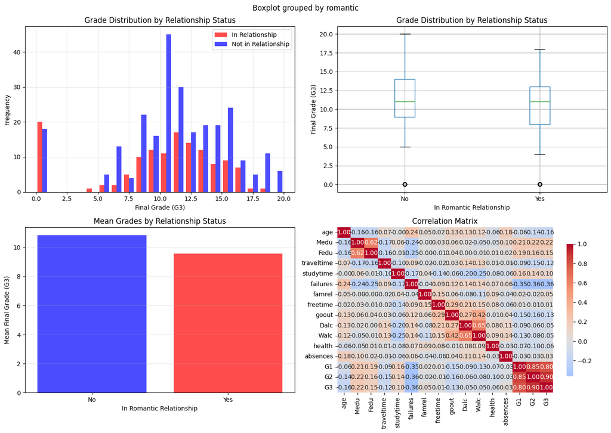

```
Correlation with G3 (target):
G3            1.000000
G2            0.904868
G1            0.801468
Medu          0.217147
Fedu          0.152457
studytime     0.097820
famrel        0.051363
absences      0.034247
freetime      0.011307
Walc         -0.051939
Dalc         -0.054660
health       -0.061335
traveltime   -0.117142
goout        -0.132791
age          -0.161579
failures     -0.360415
Name: G3, dtype: float64
```

```python
# Grade statistics by relationship status
print("Grade Statistics by Relationship Status:")
grouped_stats = data.groupby('romantic')['G3'].agg(['mean', 'median', 'std', 'count'])
print(grouped_stats)
print()

# Visualizations
fig, axes = plt.subplots(2, 2, figsize=(14, 10))

# Plot 1: Histograms
group_yes = data[data['romantic'] == 'yes']['G3']
group_no = data[data['romantic'] == 'no']['G3']

axes[0, 0].hist([group_yes, group_no], label=['In Relationship', 'Not in Relationship'], alpha=0.7, bins=20, color=['red', 'blue'])
axes[0, 0].set_xlabel('Final Grade (G3)')
axes[0, 0].set_ylabel('Frequency')
axes[0, 0].set_title('Grade Distribution by Relationship Status')
axes[0, 0].legend()
axes[0, 0].grid(True, alpha=0.3)

# Plot 2: Box plots
data.boxplot(column='G3', by='romantic', ax=axes[0, 1])
axes[0, 1].set_xlabel('In Romantic Relationship')
axes[0, 1].set_ylabel('Final Grade (G3)')
axes[0, 1].set_title('Grade Distribution by Relationship Status')
plt.sca(axes[0, 1])
plt.xticks([1, 2], ['No', 'Yes'])

# Plot 3: Mean comparison
romantic_means = data.groupby('romantic')['G3'].mean()
axes[1, 0].bar(['No', 'Yes'], romantic_means, alpha=0.7, color=['blue', 'red'])
axes[1, 0].set_xlabel('In Romantic Relationship')
axes[1, 0].set_ylabel('Mean Final Grade (G3)')
axes[1, 0].set_title('Mean Grades by Relationship Status')
axes[1, 0].grid(True, alpha=0.3, axis='y')

# Plot 4: Correlation heatmap
numeric_cols = data.select_dtypes(include=[np.number]).columns
correlation = data[numeric_cols].corr()
sns.heatmap(correlation, annot=True, fmt='.2f', cmap='coolwarm', center=0, ax=axes[1, 1], cbar_kws={'shrink': 0.8})
axes[1, 1].set_title('Correlation Matrix')

plt.tight_layout()
plt.savefig('eda_visualizations.png', dpi=300, bbox_inches='tight')
print("Visualizations saved as 'eda_visualizations.png'")
plt.show()

print()
print("Correlation with G3 (target):")
print(correlation['G3'].sort_values(ascending=False))
print()
```

# Feature Engineering

Engineered the feature "romantic_encoded" to take all of the "yes" values from the romantic feature. This feature will then be used for the linear regression model.

```python
data['romantic_encoded'] = (data['romantic'] == 'yes').astype(int)
print()

# include romantic_encoded and exclude the original romantic column
feature_cols = [col for col in data.columns if col not in ['G3', 'romantic'] and data[col].dtype in ['int64', 'float64']]

print(f"Selected {len(feature_cols)} features for modeling:")
for feat in feature_cols:
    print(f"  - {feat}")
print()

# Define features (X) and target (y)
X = data[feature_cols]
y = data['G3']

print(f"Feature matrix X shape: {X.shape}")
print(f"Target vector y shape: {y.shape}")
print()

# Split into training and test sets (80-20 split)
X_train, X_test, y_train, y_test = train_test_split(
    X, y, test_size=0.2, random_state=42
)

print(f"Training set: {len(X_train)} samples")
print(f"Test set: {len(X_test)} samples")
print()

# Scale the features
scaler = StandardScaler()
X_train_scaled = scaler.fit_transform(X_train)
X_test_scaled = scaler.transform(X_test)

# Convert back to DataFrame
X_train_scaled = pd.DataFrame(X_train_scaled, columns=feature_cols, index=X_train.index)
X_test_scaled = pd.DataFrame(X_test_scaled, columns=feature_cols, index=X_test.index)

print("Features scaled (mean=0, std=1)")
print()
```

```
Selected 16 features for modeling:
  - age
  - Medu
  - Fedu
  - traveltime
  - studytime
  - failures
  - famrel
  - freetime
  - goout
  - Dalc
  - Walc
  - health
  - absences
  - G1
  - G2
  - romantic_encoded

Feature matrix X shape: (395, 16)
Target vector y shape: (395,)

Training set: 316 samples
Test set: 79 samples

Features scaled (mean=0, std=1)
```

# Predictive Modeling

A linear regression model was created to quantify the relationship between romantic involvement and academic performance while controlling for other variables. The dataset was split into training and testing sets, and all numeric features, including the encoded relationship variable, were used as predictors. The model's coefficients were examined to determine the relative influence of each feature on final grade outcomes.

```python
#Linear Regression Model
model_lr = LinearRegression()
model_lr.fit(X_train_scaled, y_train)

# Feature coefficients
coef_df = pd.DataFrame({
    'Feature': feature_cols,
    'Coefficient': model_lr.coef_
}).sort_values('Coefficient', key=abs, ascending=False)

print()
print("Top 10 Most Important Features:")
print(coef_df.head(10))
print()

# Check romantic relationship coefficient
romantic_coef = coef_df[coef_df['Feature'] == 'romantic_encoded']
if len(romantic_coef) > 0:
    coef_value = romantic_coef['Coefficient'].values[0]
    rank = list(coef_df['Feature']).index('romantic_encoded') + 1
    print(f"Romantic Relationship:")
    print(f"Coefficient: {coef_value:.4f}")
```

```
Top 10 Most Important Features:
             Feature  Coefficient
14                G2     3.605686
13                G1     0.569606
12          absences     0.406980
5           failures    -0.286043
6             famrel     0.278313
15  romantic_encoded    -0.240353
0                age    -0.220245
2               Fedu    -0.202276
8              goout     0.138618
1               Medu     0.117560

Romantic Relationship:
Coefficient: -0.2404
```